# Electrotarsogram Responses of *Varroa destructor*, a Primary Pest of Western Honey Bees (*Apis mellifera* L.)

Michael Light & Joel Goodwin

2018-01-30

# Introduction

## Background Information

Honeybees are very important organisms to the world at large. Honeybees are important pollinators of flowering plants, and thus are essential to the agriculture industry. Despite their vital importance, honeybee populations have been declining for nearly thirty years. One of the main reasons for this decline in honeybee numbers is the Varroa mite (*Varroa destructor*), an external parasite of honeybees. Varroa mites are responsible for causing Varroosis in honeybees, weakening adult bees by feeding on their haemolymph and thereby increasing their susceptibility to other diseases. The current protocol in place to help rid honeybee colonies of Varroa mites is through miticides. However, this method of pest control is not sustainable as the use of miticides may further weaken the honeybees or contaminate hive products. More importantly, an increase in resistance to miticides by Varroa mites has been seen. Consequently, it is imperative to develop a new means of controlling these pests to increase honeybee populations in the long term.

## Research Objectives

This research aims to examine various odorants and their effects on both Varroa mites and honeybees to analyze their attractant or repellent properties on the two species. Additionally, the effects of the odorants on honeybee and Varroa mite behaviour, as well as effects on in-hive production, will be examined.

The outcome of this research project will be to implement the use of odorants as a more sustainable means of controlling Varroa mite populations, without the use of toxic pesticides. Successful implementation of the results of this study could help slow the decline of honeybee populations worldwide by decreasing the presence of Varroa mites in honeybee colonies.

## Progress

Over the summer, Mike conducted electrotarsograms (ETGs) on Varroa mites to examine their physiological sensitivity to several previously identified attractive odourants.

## Questions

The questions we want to answer from the dataset are as follows:  
1. Are there mite trials that are outliers? 2. Are there odours which consistantly evoke a response?  
3. Are there concentration-dependent trends?  
- do mites become habituated to odours of a given concentration? 4. Can we quantify and account for between-trial (between-mite) variability?

# Loading Data and Packages

```r
my.df <- read_csv('DataForR.csv')
```

### Look at Data

```r
str(my.df)
```

```
## Classes 'tbl_df', 'tbl' and 'data.frame':    1165 obs. of  6 variables:
##  $ trial     : int  1 1 1 1 1 1 1 1 1 1 ...
##  $ odour     : chr  "2-Hydroxyhexanoic Acid (DCM)" "2-Hydroxyhexanoic Acid (DCM)" "2-Hydroxyhexanoic Acid (DCM)" "Methyl Palmitate" ...
##  $ conc      : num  0.01 0.1 1 0.01 0 10 0.01 1 0.01 0.1 ...
##  $ percent   : num  53.6 142.5 157.9 137.7 100 ...
##  $ gb        : chr  "Good" "Good" "Good" "Good" ...
##  $ normalized: num  13.3 129.8 136.7 127.4 100 ...
##  - attr(*, "spec")=List of 2
##   ..$ cols   :List of 6
##   .. ..$ trial     : list()
##   .. .. ..- attr(*, "class")= chr  "collector_integer" "collector"
##   .. ..$ odour     : list()
##   .. .. ..- attr(*, "class")= chr  "collector_character" "collector"
##   .. ..$ conc      : list()
##   .. .. ..- attr(*, "class")= chr  "collector_double" "collector"
##   .. ..$ percent   : list()
##   .. .. ..- attr(*, "class")= chr  "collector_double" "collector"
##   .. ..$ gb        : list()
##   .. .. ..- attr(*, "class")= chr  "collector_character" "collector"
##   .. ..$ normalized: list()
##   .. .. ..- attr(*, "class")= chr  "collector_double" "collector"
##   ..$ default: list()
##   .. ..- attr(*, "class")= chr  "collector_guess" "collector"
##   ..- attr(*, "class")= chr "col_spec"
```

```r
summary(my.df)
```

```
##      trial          odour                conc           percent
##  Min.   : 1.00   Length:1165        Min.   : 0.000   Min.   :  17.59
##  1st Qu.: 9.00   Class :character   1st Qu.: 0.010   1st Qu.:  78.07
##  Median :13.00   Mode  :character   Median : 0.100   Median : 100.00
##  Mean   :12.22                      Mean   : 2.665   Mean   : 117.17
##  3rd Qu.:16.00                      3rd Qu.: 1.000   3rd Qu.: 125.02
##  Max.   :18.00                      Max.   :10.000   Max.   :2507.58
##       gb              normalized
##  Length:1165        Min.   :-368.60
##  Class :character   1st Qu.:  71.91
##  Mode  :character   Median : 100.00
##                     Mean   :  89.80
##                     3rd Qu.: 120.01
##                     Max.   : 196.01
```

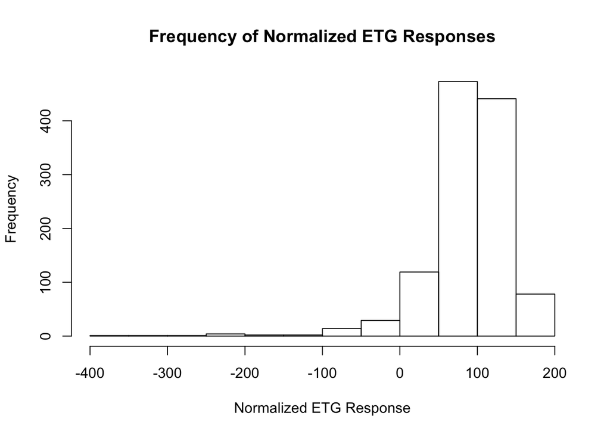

```r
hist(my.df$normalized,
     xlab="Normalized ETG Response", ylab="Frequency",
     main="Frequency of Normalized ETG Responses")
```

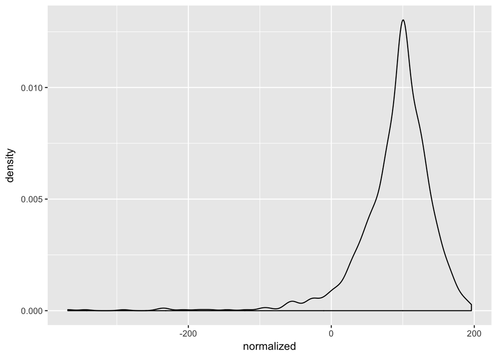

```r
p <- ggplot(data=my.df, aes(normalized))
p + geom_density()
```

## Changing Trial number and Concentration to Factors

```r
#change integer to factor for trials
my.df$trial<-factor(my.df$trial)

#lists the levels of factors
levels(my.df$trial)
```

```
##  [1] "1"  "2"  "4"  "5"  "6"  "7"  "8"  "9"  "10" "11" "12" "13" "14" "15"
## [15] "16" "17" "18"
```

```r
#change number to factor for concentration "conc"
my.df$conc<-factor(my.df$conc)
levels(my.df$conc)
```

```
## [1] "0"    "0.01" "0.1"  "1"    "10"
```

```r
# types of odours
my.df$odour<-factor(my.df$odour)
levels(my.df$odour)
```

```
##  [1] "1-Hexadecanol"                "2-Heptanol"
##  [3] "2-Heptanone"                  "2-Hydroxyhexanoic Acid (DCM)"
##  [5] "2-Nonanal"                    "Benzoic Acid"
##  [7] "Butyric Acid"                 "Dodecyl Aldehyde"
##  [9] "Ethyl Palmitate"              "Geraniol"
## [11] "Heptacosane"                  "Heptadecane"
## [13] "Hexadecanal"                  "Hexane"
## [15] "Methyl Oleate"                "Methyl Palmitate"
## [17] "Octadecanol"                  "Octanoic Acid"
## [19] "Palmitic Acid"                "trans-Nerolidol"
```

# Creating a Faceted Plot for All Odours at All Concentrations

## Step1: Filter Out Bad Runs

We discovered that these runs were highly variable and produced messy plots, so we will remove them for now.

```r
good_runs<- filter(my.df,
                    !(odour %in% c("1-Hexadecanol", "Methyl Palmitate", "Hexane",   "Palmitic Acid" )))
```

## Step2: Normalize Scores at Zero Instead of 100

```r
subsetted <- mutate(good_runs,
                    Zresponse = normalized - 100)
```

### Look at Normalized Data Distribution

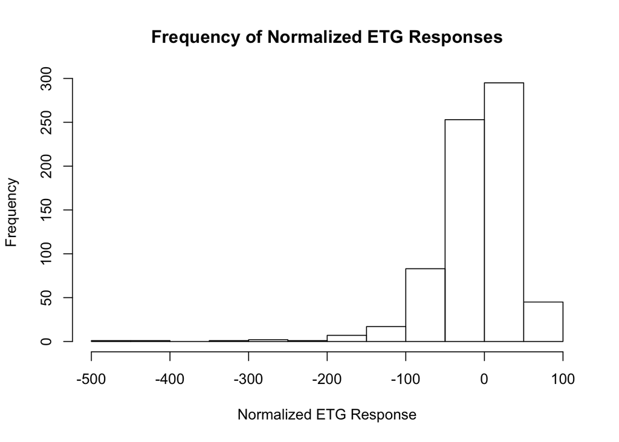

```r
hist(subsetted$Zresponse,xlab="Normalized ETG Response",ylab="Frequency", main="Frequency of Normalized ETG Responses")
```

## Step3: Filter Out Negative Responses

A negative response makes no sense physiologically, so this is an indication of a bad run. We remove these negative values from analysis.

```r
nonegatives <- subsetted %>%
  mutate(Zresponse= ifelse(Zresponse <0, NA, Zresponse))
str(nonegatives)
```

```
## Classes 'tbl_df', 'tbl' and 'data.frame':    706 obs. of  7 variables:
##  $ trial     : Factor w/ 17 levels "1","2","4","5",..: 1 1 1 1 1 1 1 1 1 1 ...
##  $ odour     : Factor w/ 20 levels "1-Hexadecanol",..: 4 4 4 15 12 12 12 2 5 5 ...
##  $ conc      : Factor w/ 5 levels "0","0.01","0.1",..: 2 3 4 5 2 3 4 3 2 3 ...
##  $ percent   : num  53.6 142.5 157.9 202.7 44.1 ...
##  $ gb        : chr  "Good" "Good" "Good" "Good" ...
##  $ normalized: num  13.3 129.8 136.7 150.7 -27 ...
##  $ Zresponse : num  NA 29.8 36.7 50.7 NA ...
```

## Step4: Make the Plot

Now that we have manipulated the data in a way that is useful to us, we will make our faceted plot.

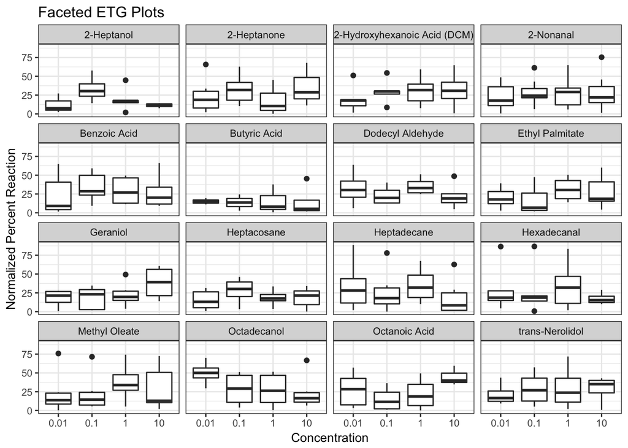

```r
ggplot(nonegatives)+
  geom_boxplot(aes(x=conc,y= Zresponse, group= conc))+
  xlab("Concentration")+ylab("Normalized Percent Reaction")+ggtitle("Faceted ETG Plots")+
  theme_bw(10)+
  facet_wrap(~odour)
```

From this plot, we can see the overall trend in ETG responses from Varroa mites at each concentration for each compound tested.

## Step5: Taking temperature and humidity into account

```r
absoluteweather<- read.csv('absoluteweather.csv')

library(tidyverse)
absoluteweather$conc <- factor(absoluteweather$conc)
absoluteweather$trial <- factor(absoluteweather$trial)
str(absoluteweather)
```

```
## 'data.frame':    1165 obs. of  12 variables:
##  $ trial     : Factor w/ 17 levels "1","2","4","5",..: 1 1 1 1 1 1 1 1 1 1 ...
##  $ odour     : Factor w/ 20 levels "1-Hexadecanol",..: 4 4 4 16 14 15 1 16 12 12 ...
##  $ conc      : Factor w/ 5 levels "0","0.01","0.1",..: 2 3 4 2 1 5 2 4 2 3 ...
##  $ percent   : num  53.6 142.5 157.9 137.7 100 ...
##  $ gb        : Factor w/ 2 levels "Bad","Good": 2 2 2 2 2 2 2 2 2 2 ...
##  $ normalized: num  13.3 129.8 136.7 127.4 100 ...
##  $ absamp    : num  -3.685 1.381 2.296 1.244 -0.801 ...
##  $ humid     : num  69 69 69.1 69.2 69.3 ...
##  $ temp      : num  20.8 20.8 20.8 20.7 20.7 ...
##  $ dewp      : num  14.9 14.9 14.9 14.9 14.9 ...
##  $ hour      : num  2013 2014 2014 2016 2019 ...
##  $ min       : num  13.1 13.8 14.5 16 18.9 ...
```

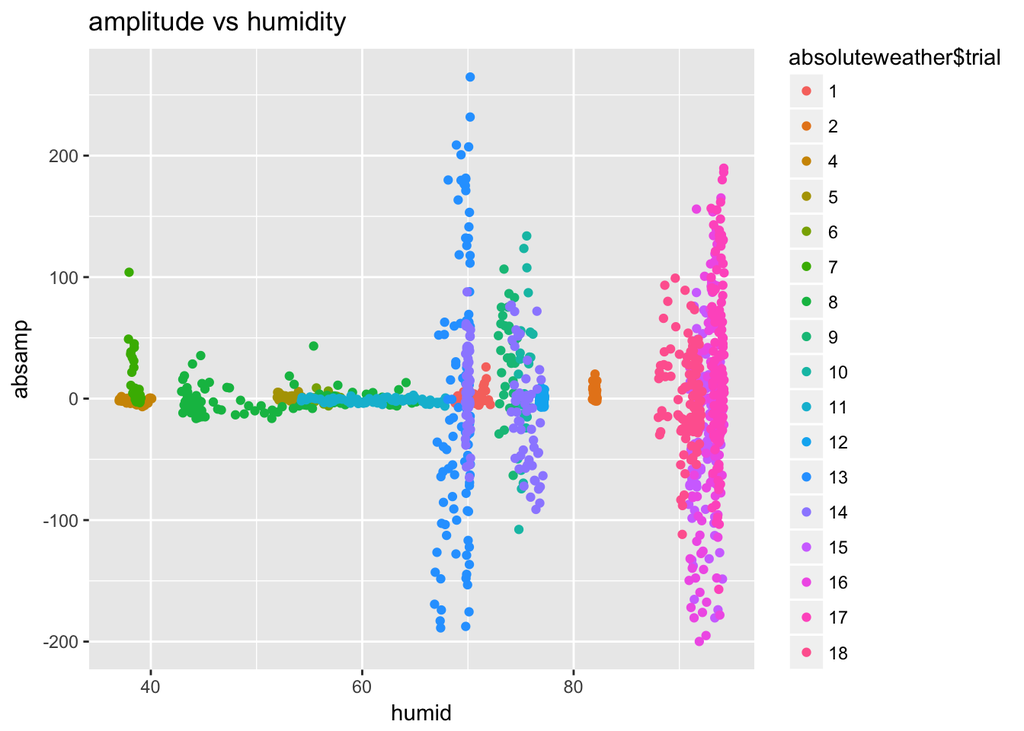

```r
ggplot(data = absoluteweather, mapping = aes(humid, absamp)) +
  geom_jitter(aes(colour = absoluteweather$trial), width = 0.25) +
  ggtitle("amplitude vs humidity")
```

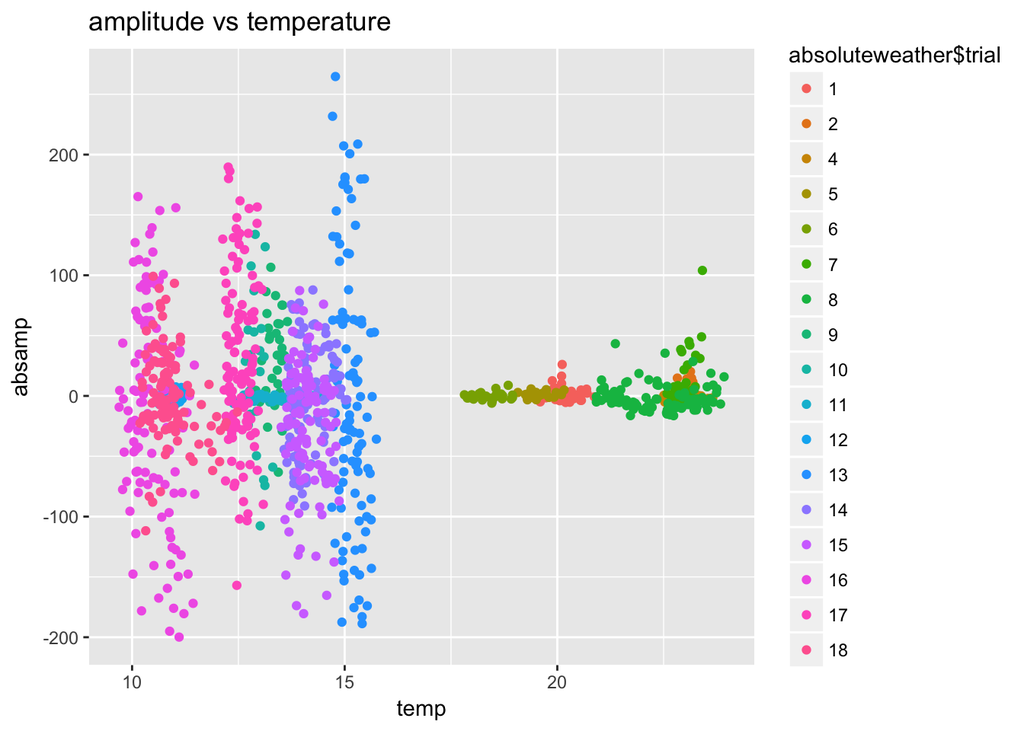

```r
ggplot(data = absoluteweather, mapping = aes(temp, absamp)) +
  geom_jitter(aes(colour = absoluteweather$trial), width = 0.25) +
  ggtitle("amplitude vs temperature")
```

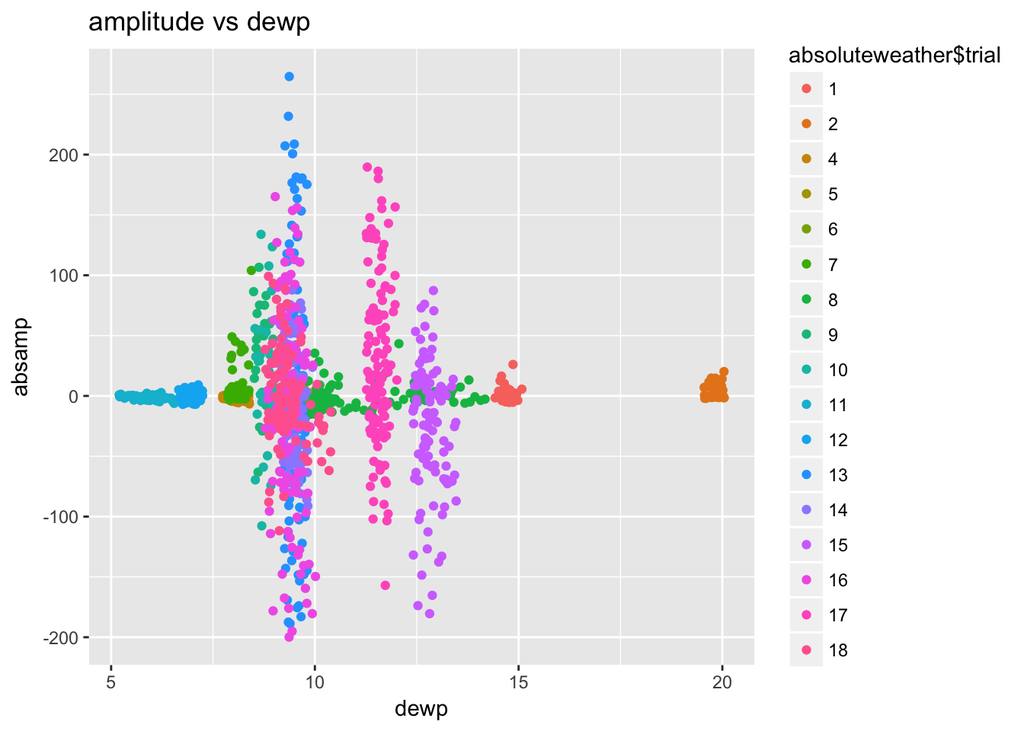

```r
ggplot(data = absoluteweather, mapping = aes(dewp, absamp)) +
  geom_jitter(aes(colour = absoluteweather$trial), width = 0.25) +
  ggtitle("amplitude vs dewp")
```

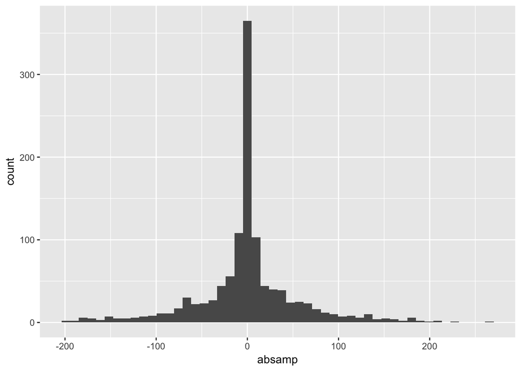

```r
ggplot(data = absoluteweather, mapping = aes(absamp))+
  geom_histogram(bins = 50)
```

```r
# correlations
cor(absoluteweather$absamp, absoluteweather$temp)
```

```
## [1] 0.0008003561
```

```r
cov(absoluteweather$absamp, absoluteweather$temp)
```

```
## [1] 0.1944014
```

```r
corr_amp_tempr <- cor.test(x=absoluteweather$absamp,
                           y=absoluteweather$temp, method = 'spearman')
corr_amp_tempr
```

```
##
##  Spearman's rank correlation rho
##
## data:  absoluteweather$absamp and absoluteweather$temp
## S = 268850000, p-value = 0.4909
## alternative hypothesis: true rho is not equal to 0
## sample estimates:
##         rho
## -0.02020084
```

```r
corr_amp_humid <- cor.test(x=absoluteweather$absamp,
                           y=absoluteweather$humid, method = 'spearman')
corr_amp_humid
```

```
##
##  Spearman's rank correlation rho
##
## data:  absoluteweather$absamp and absoluteweather$humid
## S = 260540000, p-value = 0.6995
## alternative hypothesis: true rho is not equal to 0
## sample estimates:
##        rho
## 0.01132207
```

```r
corr_amp_dewp<- cor.test(x=absoluteweather$absamp,
                         y=absoluteweather$dewp, method = 'spearman')
corr_amp_dewp
```

```
##
##  Spearman's rank correlation rho
##
## data:  absoluteweather$absamp and absoluteweather$dewp
## S = 281170000, p-value = 0.0223
## alternative hypothesis: true rho is not equal to 0
## sample estimates:
##         rho
## -0.06695036
```

```r
library(fifer)
```

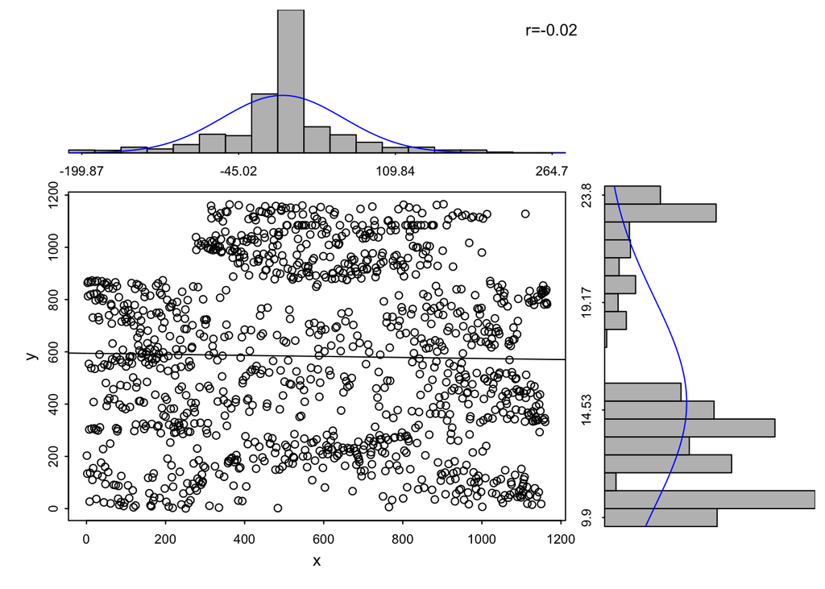

```r
spearman.plot(absoluteweather$absamp, absoluteweather$temp)
```

```r
weather_matrix <- data.matrix(absoluteweather[7:10], rownames.force = NA)
```

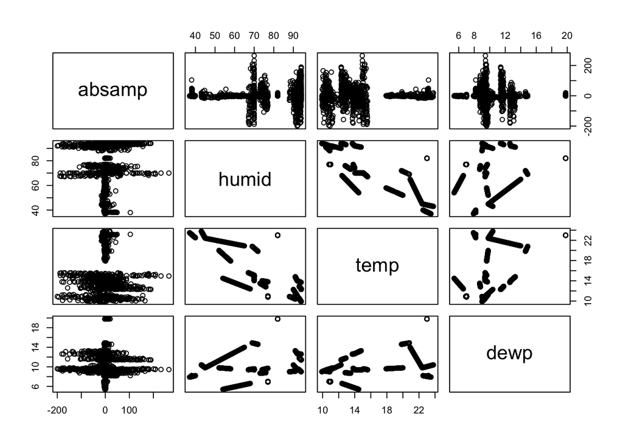

```r
pairs(weather_matrix) # plots all the stuff simultaneiously
```

# Plotting absolute amplitude (corrected to Hexane blank) versus time of trial.

Step1: Normalize scores at zero

Step2: Filter out negative responses

```
##  num [1:1165] NA 29.8 36.7 27.4 0 ...
```

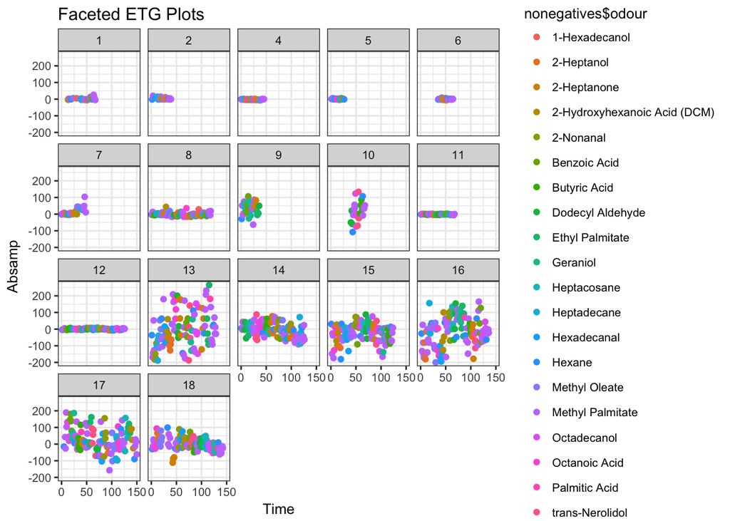

```r
ggplot(data = nonegatives, aes(min, absamp))+
  geom_jitter(aes(colour = nonegatives$odour), width = 0.25)+
  xlab("Time")+ylab("Absamp")+ggtitle("Faceted ETG Plots")+
  theme_bw(10)+
  facet_wrap(~trial)
```